# Sesión 7 - Modelos de Vectores Autorregresivos

Universidad Nacional de Colombia - Facultad de Ciencias Económicas

Monitorías Econometría II

2023-02

En esta sesión introduciremos los modelos de vectores autorregresivos en R, el objetivo principal de la sesión es comprender el funcionamiento de la programación de los modelos VAR. Además, se analizaran métodos y funciones para graficar, simular y manipular series multivariadas. Se usará la metoodlogía Box-Jenkins multiecuacional e introduciremos las gráficas de impulso respuesta.

La sesión se divide en dos partes. Una primera parte con una ilustración del proceso con series simuladas y una segunda parte donde generaremos el proceso con un ejemplo del libro de Enders, el cual considera un VAR con tres variables: Índice de producción industrial, el índice de precios al consumidor y la tasa de desempleo (todas las variables de Estados Unidos).

## Instalación de paquetes

Para estas sesión traemos por primera vez el paquete “vars” el cual nos permitirá usar modelos de vectores autorregresivos.

```r
library(pacman)

pacman::p_load(

  vars,        # Para usar modelos VAR
  urca,        # Para realizar pruebas de raíz unitaria
  ggfortify,   # Para graficar series de tiempo
  gridExtra,   # Para crear gráficos de análisis exploratorio de datos
  tidyverse,   # Paquete que incluye ggplot2 y dplyr
  tidyr,       # Para manipular y organizar datos
  readxl       # Para leer archivos .xlsx
)
```

# 1. Creación de serie simulada

En esta sección crearemos dos series simuladas para ilustrar el mecanismo de los VAR, vamos a simular un modelo VAR(1) en dos variables. En consecuencia, la matriz A_1 será de dimensiones 2x2 y tendrá como componentes: a11=0.3; a12=0.2; a21=0.5; a22=0.6. En este ejemplo asumimos que conocemos el verdadero PGD, aunque en la vida real esto no es posible.

En primer lugar, se fija una semilla para obtener los mismos resultados.

```r
set.seed(82901)
```

Ahora, crearemos las variables simuladas y las incluiremos en un matriz Tx2. Por lo que fijamos un número de T observaciones y creamos el vector.

```r
T = 300



y_t <- cbind(rep(0, T),rep(0, T))
```

En tanto hay dos variables, habrá 2 residuales. Supondrémos que se distribuyen normal.

```r
u_t = cbind(rnorm(T), rnorm(T))
```

Creamos la matriz A_1, que contiene los coeficientes del primer rezago.

```r
A_1 = cbind(c(0.3, 0.5), c(0.2, 0.6))
```

Ahora, crearemos una función “sim” que nos permitirá simular lo datos para cada variable que hemos creado.

```r
sim = function(y_t, A_1, u_t, T){
  for (i in 2:T) {
    y_t[i,] = A_1 %*% y_t[i-1,] + u_t[i,]
  }
  return(y_t)
}


y_t = sim(y_t, A_1, u_t, T) # La función sim lo que busca es llenar la matriz
                            # de ceros y_t con valores
```

Una vez creada la matriz de datos, la convertimos en una serie de tiempo multivariada usando la función ts()

```r
y_t=ts(y_t, start=c(1900,1), frequency=4)
```

Analicemos el comportamiento gráfico de la serie creada. Con grid.arrange(), podremos incluir varias gráficas en un solo Plot.

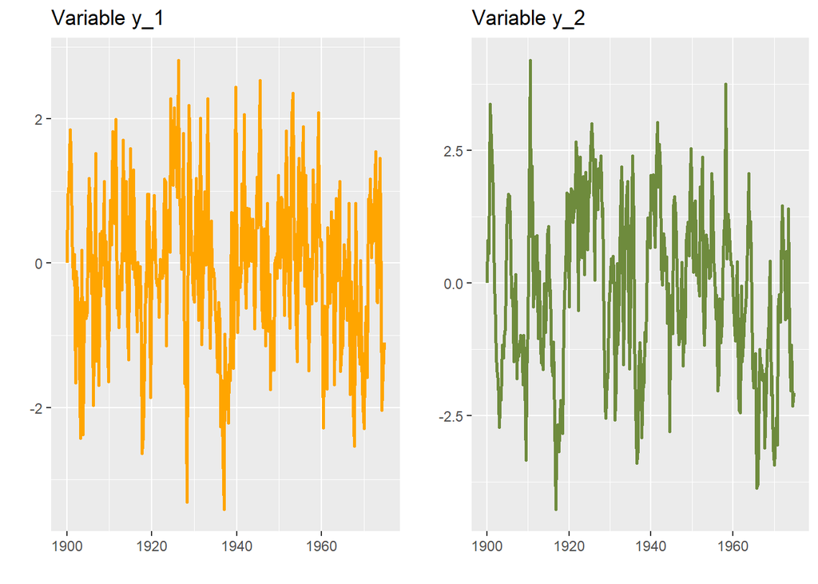

```r
y1 = autoplot(y_t[,1], size=1,ts.colour="orange", xlab="",ylab="",
              main="Variable y_1")
y2 = autoplot(y_t[,2], size=1,ts.colour="darkolivegreen4", xlab="",ylab="",
              main="Variable y_2")

grid.arrange(y1,y2,ncol=2)
```

Recordemos que para usar los modelos VAR, es importante que las series empleadas sean I(0), es decir, deben ser estacionarias para usar esta metodología. En consecuencia, la gráfica anterior sugiere un comportamiento estacionario, verifiquemos con las prueba Dickey-Fuller.

```r
adf1= ur.df(y_t[,1], lags=3,selectlags = "AIC",type="none")
summary(adf1) #Rechazo H0, la serie es I(0)
```

```
##
## ###############################################
## # Augmented Dickey-Fuller Test Unit Root Test #
## ###############################################
##
## Test regression none
##
##
## Call:
## lm(formula = z.diff ~ z.lag.1 - 1 + z.diff.lag)
##
## Residuals:
##      Min       1Q   Median       3Q      Max
## -3.01314 -0.77486 -0.05968  0.67805  2.79566
##
## Coefficients:
##             Estimate Std. Error t value Pr(>|t|)
## z.lag.1     -0.50131    0.07178  -6.984 1.92e-11 ***
## z.diff.lag1 -0.14968    0.06895  -2.171   0.0307 *
## z.diff.lag2 -0.10726    0.05818  -1.844   0.0662 .
## ---
## Signif. codes:  0 '***' 0.001 '**' 0.01 '*' 0.05 '.' 0.1 ' ' 1
##
## Residual standard error: 1.032 on 293 degrees of freedom
## Multiple R-squared:  0.3194, Adjusted R-squared:  0.3124
## F-statistic: 45.83 on 3 and 293 DF,  p-value: < 2.2e-16
##
##
## Value of test-statistic is: -6.9844
##
## Critical values for test statistics:
##       1pct  5pct 10pct
## tau1 -2.58 -1.95 -1.62
```

```r
adf2= ur.df(y_t[,2], lags=3,selectlags = "AIC",type="none")
summary(adf2) #Rechazo H0, la serie es I(0)
```

```
##
## ###############################################
## # Augmented Dickey-Fuller Test Unit Root Test #
## ###############################################
##
## Test regression none
##
##
## Call:
## lm(formula = z.diff ~ z.lag.1 - 1 + z.diff.lag)
##
## Residuals:
##     Min      1Q  Median      3Q     Max
## -2.8368 -0.7592 -0.0532  0.6947  3.2507
##
## Coefficients:
##            Estimate Std. Error t value Pr(>|t|)
## z.lag.1    -0.24347    0.04181  -5.824 1.51e-08 ***
## z.diff.lag -0.07148    0.05764  -1.240    0.216
## ---
## Signif. codes:  0 '***' 0.001 '**' 0.01 '*' 0.05 '.' 0.1 ' ' 1
##
## Residual standard error: 1.081 on 294 degrees of freedom
## Multiple R-squared:  0.1381, Adjusted R-squared:  0.1322
## F-statistic: 23.55 on 2 and 294 DF,  p-value: 3.253e-10
##
##
## Value of test-statistic is: -5.8239
##
## Critical values for test statistics:
##       1pct  5pct 10pct
## tau1 -2.58 -1.95 -1.62
```

Observemos, que la prueba Dickey-Fuller indica que las series son estacionarias.